# R Markdown testbed

PSY 525

Rick Gilmore

2020-02-12 16:37:55

# 1 This is a Heading 1

## 1.1 This is a Heading 2

### 1.1.1 This is a Heading 3

# 2 Lists

## 2.1 Not enumerated

- An item
  - A nested item with **boldface**
    - A doubly-nested item with *italics*
- Another item with some text stricken out
- URL: [Penn State Home](https://www.psu.edu)

## 2.2 Enumerated

1. An enumerated item
   - A nested item
2. A second enumerated item
   1. A nested item with a footnote [^1] marker. Look for the text at the end of the document.
   2. A second nested item. See how alphabetical enumerated lists work like you’d expect.

## 2.3 Block quotation

> Four score and seven years ago, some famous President spoke infamous words that would live on throughout history. These words are famous enough that I want to highlight them with a block quote.

# 3 Make some data

```r
x = rnorm(n = 100, mean = 0, sd = 1)   # N(0,1)
y = rnorm(n = 100, mean = 2, sd = 0.5) # N(2, 0.5)
```

## 3.1 Summarize

```r
summary(x)
```

```
##     Min.  1st Qu.   Median     Mean
## -2.98124 -0.67448 -0.03216 -0.05013
##  3rd Qu.     Max.
##  0.49362  2.74005
```

```r
summary(y)
```

```
##    Min. 1st Qu.  Median    Mean 3rd Qu.
##  0.8498  1.7560  2.0870  2.0872  2.4222
##    Max.
##  3.2645
```

## 3.2 Histogram

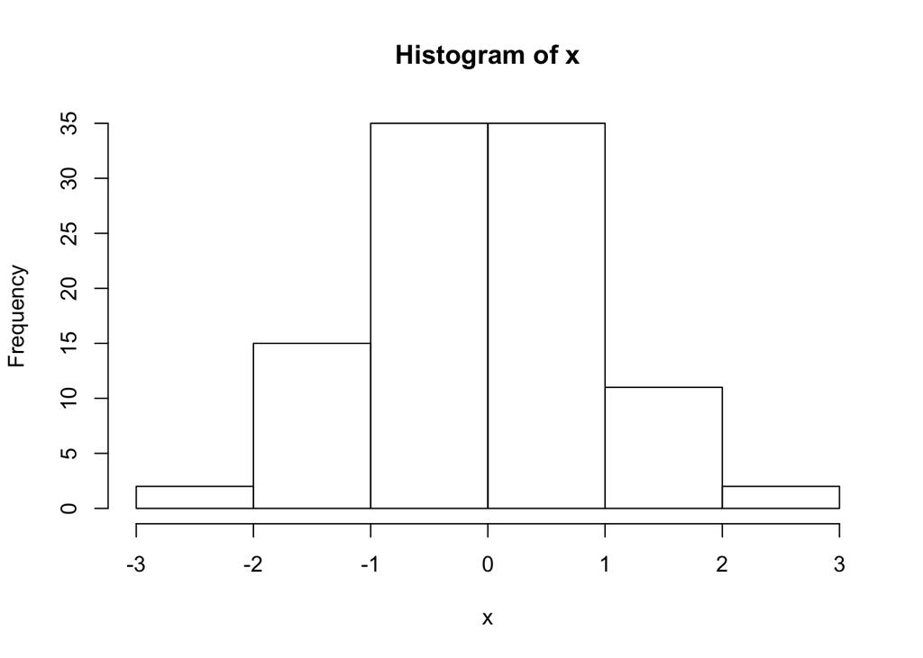

```r
hist(x)
```

## 3.3 Plot

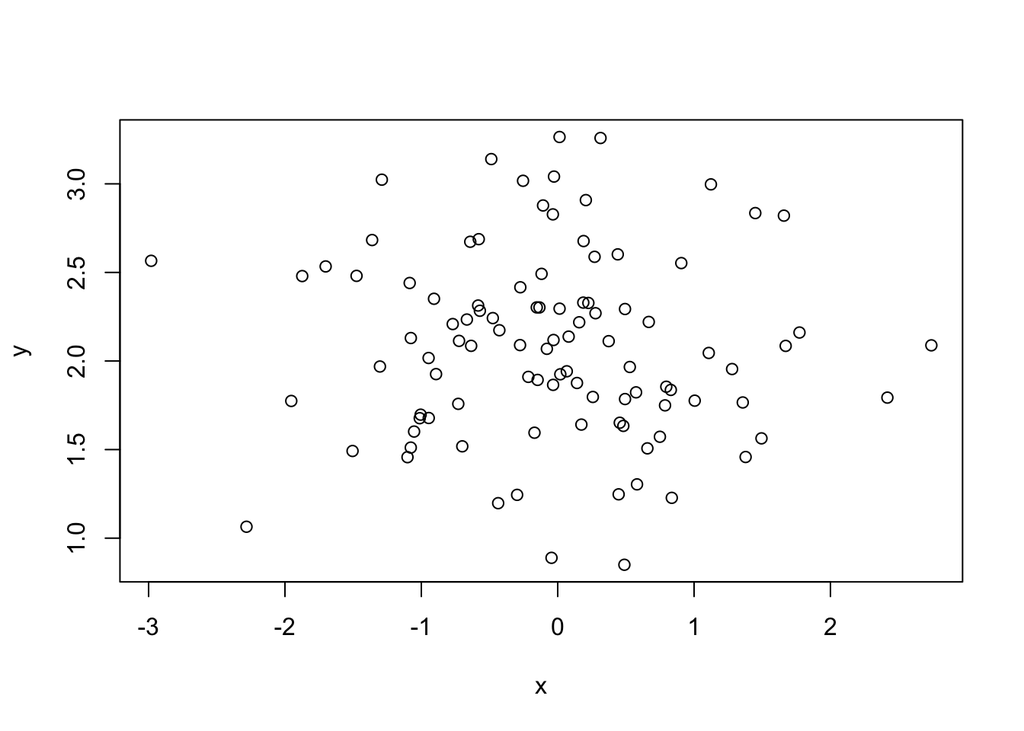

```r
plot(x,y)
```

# 4 Embed figures or videos

Some of these methods work better than others with a particular output format.

## 4.1 From the web using `knitr::include_graphics()`.

The `html_document` format is fine with using the URL as the input to `knitr::include_graphics()`, but the `pdf_document` format seems to want a local file path, hence the use of `download.file()`.

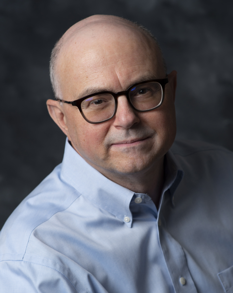

Rick’s pic from Databrary

```r
download.file("https://nyu.databrary.org/party/6/avatar",'img/rog.png', mode = 'wb')
knitr::include_graphics("img/rog.png")
```

## 4.3 From a local file using `knitr::include_graphics()`

```r
knitr::include_graphics("img/sleic.jpg")
```

[output not shown]

## 4.5 From YouTube

[video not shown]

# 5 Printing values from R

```r
summ.x = summary(x)
summ.y = summary(y)
names(summ.x) # Figure out variable names for indexing
```

```
## [1] "Min."    "1st Qu." "Median"  "Mean"
## [5] "3rd Qu." "Max."
```

*Index by variable name:* X lies within the range of [-2.9812423, 2.7400503].

*Index by numeric index:* The (y-x) difference in means is 2.1373676.

*Calculate and report:* The correlation between x and y is -0.0483962.

# 6 Math equations

$$e=mc^{2}$$

# 7 Parameterized reports

## 7.1 My name is Steve

## 7.2 My quest is to find the grail

## 7.3 My favorite color is blue

# 8 Footnotes

[^1]: Here is the footnote text. Note that it ends up at the end of the document.